# imputeTS

Dra. Martha Elva Ramírez Guzmán

2024-09-24

```r
# Load libraries
library(imputeTS)
library(ggplot2)
library(dplyr)
```

Functions: ggplot_na_imputations for the next types of imputations:

na_mean: Replaces each missing value with the mean of the present values.

na_locf: Replaces each missing value with the most recent present value prior to it.

na_kalman: Replaces each missing value with a Kalman smoothing. na_seadec: Replaces each missing value with a seasonal decomposition. The seasonal decomposition is done by stl() from the stats package. Removes the seasonal component from the time series, performs imputation on the deseasonalized series and afterwards adds the seasonal component again.

na_ma: Replaces each missing value with the moving average.

na_random: Replaces each missing value with a random value.

na_remove: Removes all missing values.

na_replace: Replaces each missing value with a specified value.

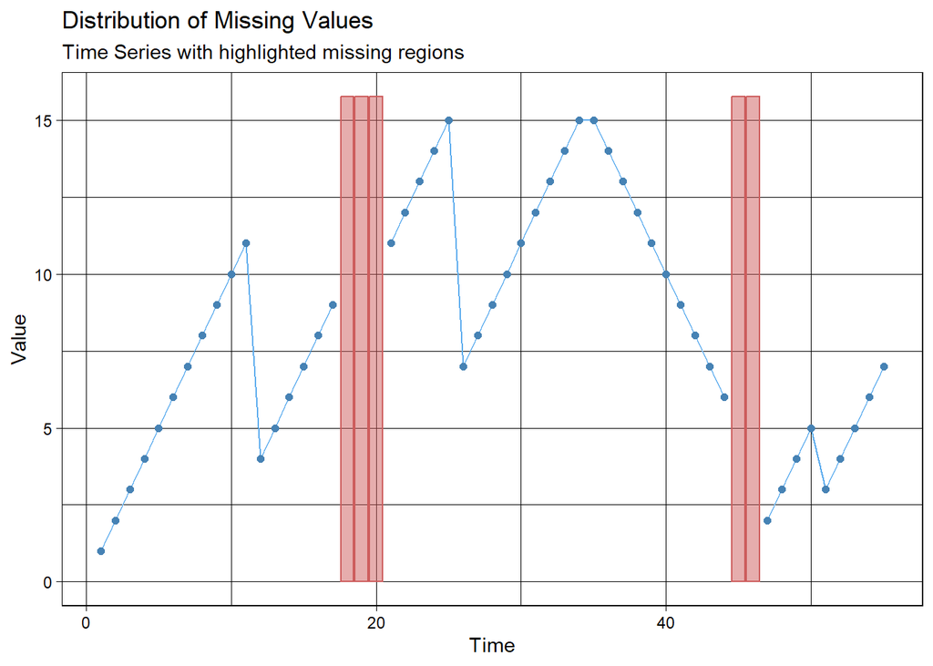

```r
x <- stats::ts(c(1:11, 4:9, NA, NA, NA, 11:15, 7:15, 15:6, NA, NA, 2:5, 3:7))
ggplot_na_distribution(x)
```

# 1.2 Visualize NAs in tsAirgap

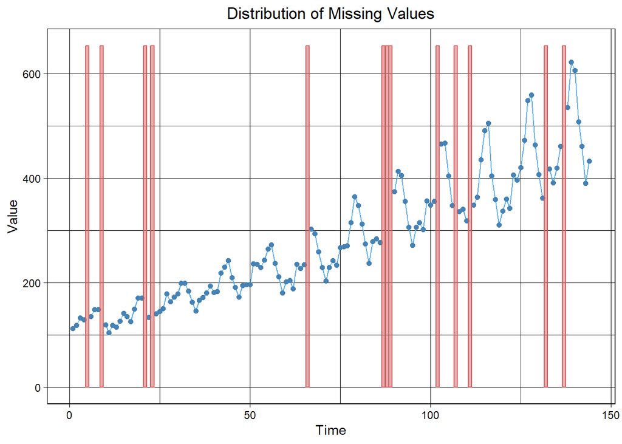

```r
ggplot_na_distribution(tsAirgap, subtitle = NULL) +
  ggplot2::theme(plot.title = ggplot2::element_text(hjust = 0.5))
```

# 2. Function: ggplot_na_ditribution2. For large time series

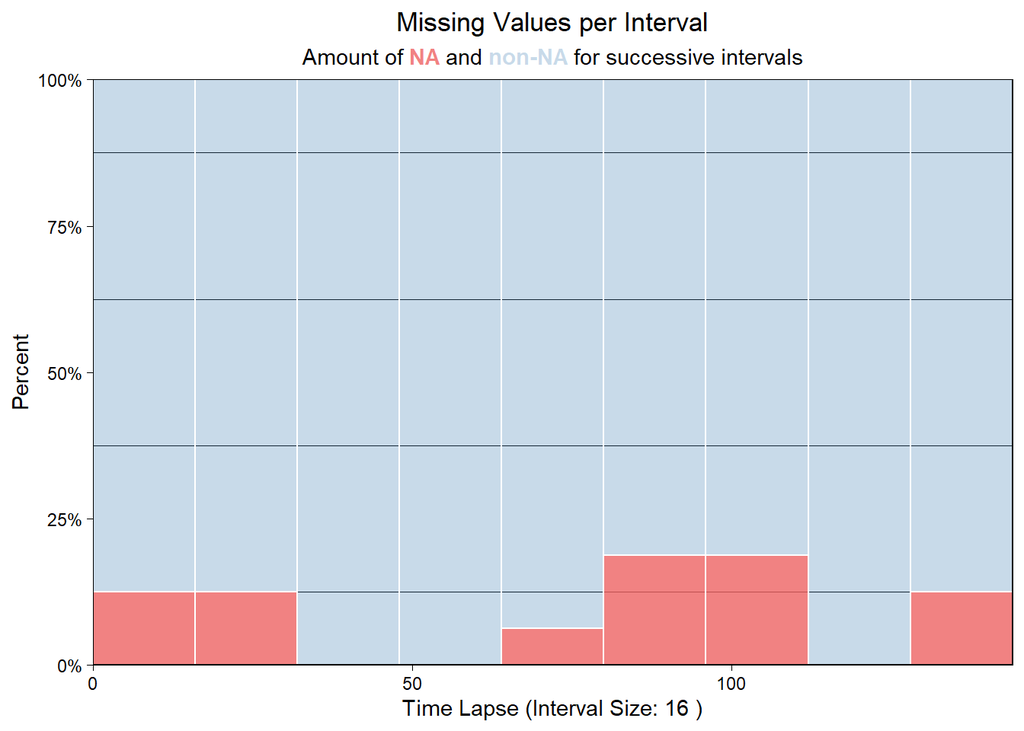

```r
ggplot_na_distribution2(tsAirgap) +
  ggplot2::theme(plot.title = ggplot2::element_text(hjust = 0.5)) +
  ggplot2::theme(plot.subtitle = ggtext::element_markdown(hjust = 0.5))
```

# 3. Function: ggplot_na_gapsize

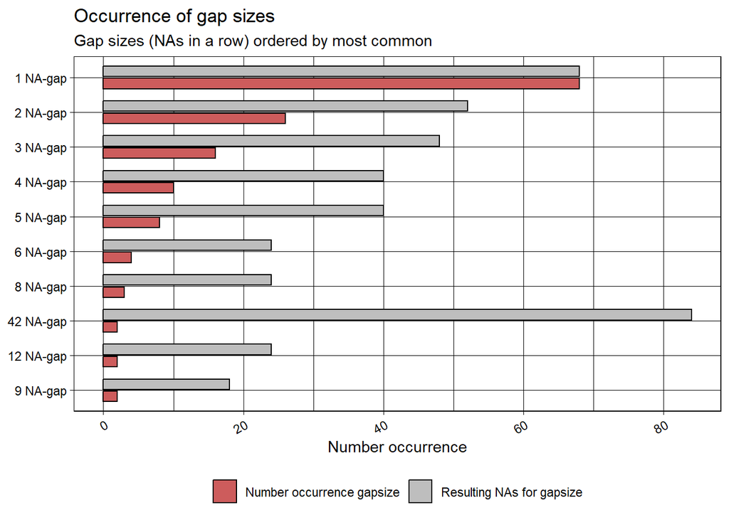

```r
ggplot_na_gapsize(tsNH4, color_total = "grey")
```

# 4. Functions: ggplot_na_imputations for the next types of imputations:

# 4.1 na_mean

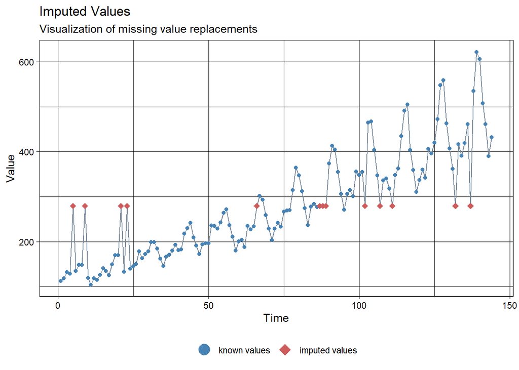

```r
imp_mean <- na_mean(tsAirgap)
ggplot_na_imputations(tsAirgap, imp_mean)
```

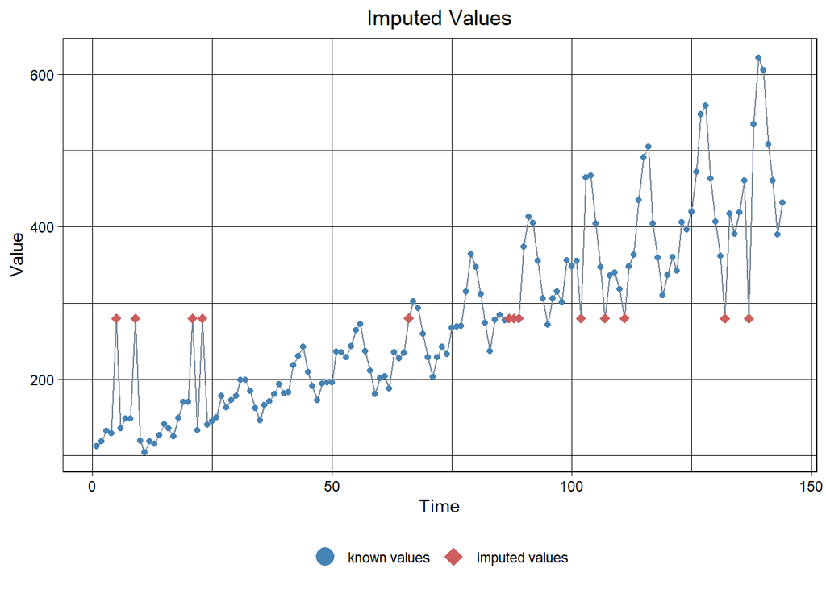

```r
imp_mean <- na_mean(tsAirgap)
ggplot_na_imputations(x_with_na = tsAirgap,
                      x_with_imputations = imp_mean,
                      subtitle = NULL) +
  ggplot2::theme(plot.title = ggplot2::element_text(hjust = 0.5))
```

# 4.2 na_locf and added ground truth

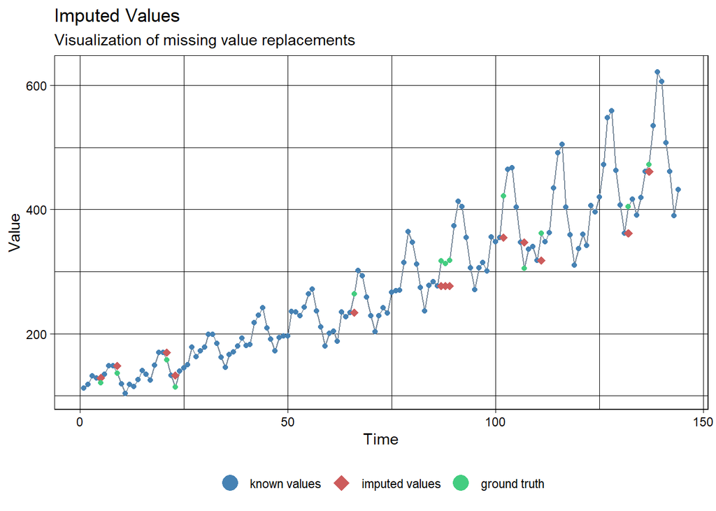

```r
imp_locf <- na_locf(tsAirgap)
ggplot_na_imputations(x_with_na = tsAirgap,
                      x_with_imputations = imp_locf,
                      x_with_truth = tsAirgapComplete
)
```

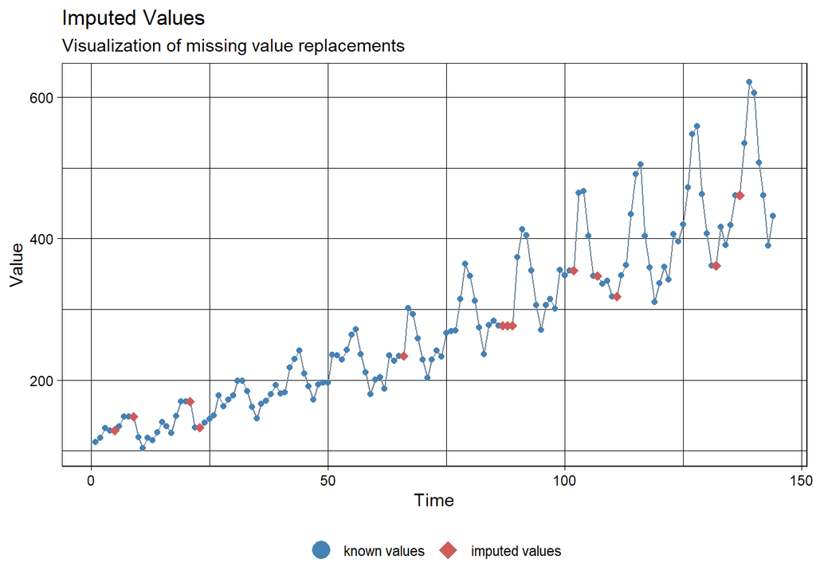

```r
imp_locf <- na_locf(tsAirgap)
ggplot_na_imputations(x_with_na = tsAirgap, x_with_imputations = imp_locf)
```

# 4.3 na_kalman

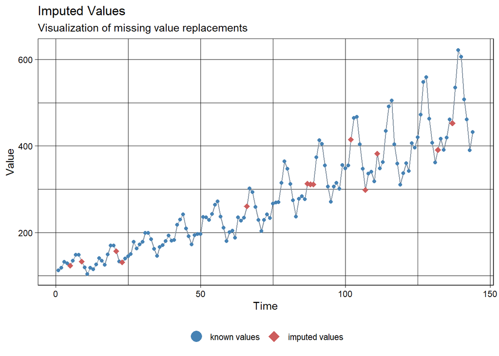

```r
imp_kalman <- na_kalman(tsAirgap)
ggplot_na_imputations(x_with_na = tsAirgap, x_with_imputations = imp_kalman)
```

# 4.4 na_seadec

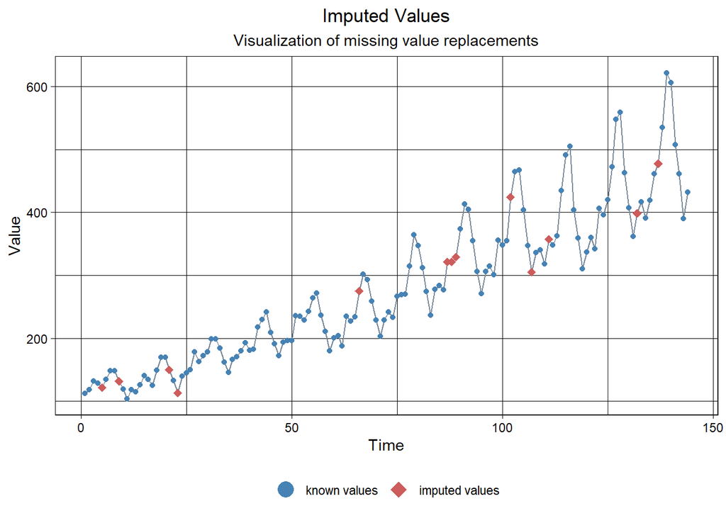

```r
imp_seadec <- na_seadec(tsAirgap)
ggplot_na_imputations(x_with_na = tsAirgap, x_with_imputations = imp_seadec) +
  ggplot2::theme(plot.title = ggplot2::element_text(hjust = 0.5)) +
  ggplot2::theme(plot.subtitle = ggplot2::element_text(hjust = 0.5))
```

# 4.5.1 na_ma: Perform imputation with simple moving average

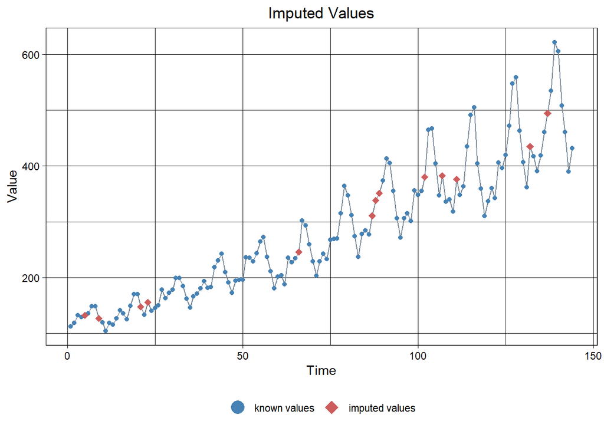

```r
imp_na_ma<-na_ma(tsAirgap, weighting = "simple")
ggplot_na_imputations(x_with_na = tsAirgap,
                      x_with_imputations = imp_na_ma,
                      subtitle = NULL) +
  ggplot2::theme(plot.title = ggplot2::element_text(hjust = 0.5))
```

# 4.5.2: Imputation with EXPONENCIAL weighted moving average window size=6

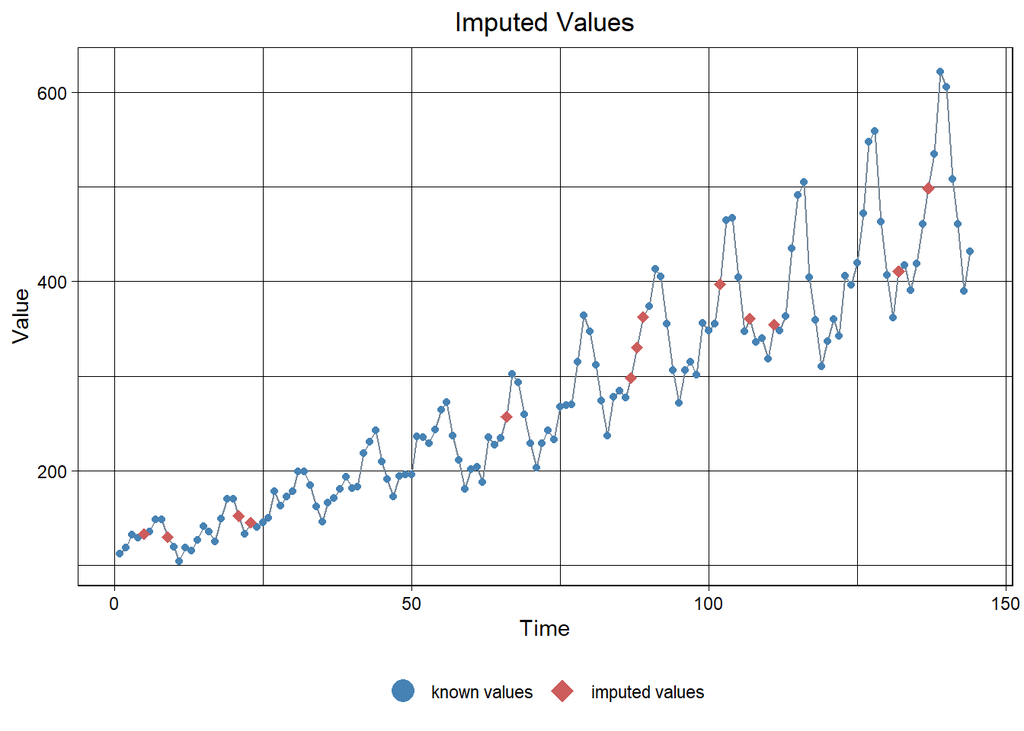

```r
imp_na_ma_6<-na_ma(tsAirgap, k = 6)
ggplot_na_imputations(x_with_na = tsAirgap,
                      x_with_imputations = imp_na_ma_6,
                      subtitle = NULL) +
  ggplot2::theme(plot.title = ggplot2::element_text(hjust = 0.5))
```

# 4.5.3: Same as example 1, just written with pipe operator

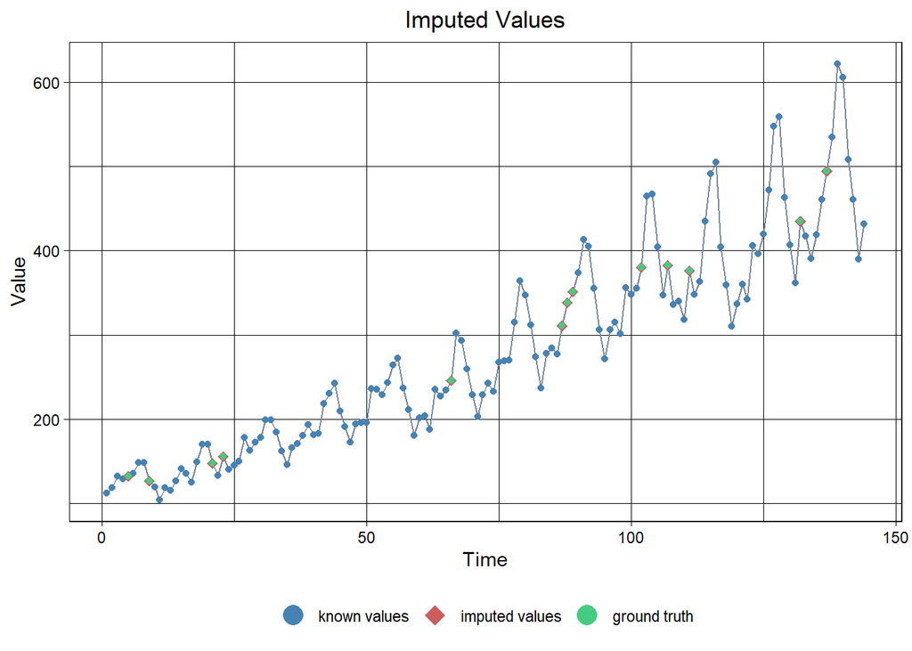

```r
tsAirgap %>% na_ma(weighting = "simple") %>%
  ggplot_na_imputations(x_with_na = tsAirgap,
                        x_with_imputations = imp_na_ma,
                        subtitle = NULL) +
  ggplot2::theme(plot.title = ggplot2::element_text(hjust = 0.5))
```

# 4.6 na_random

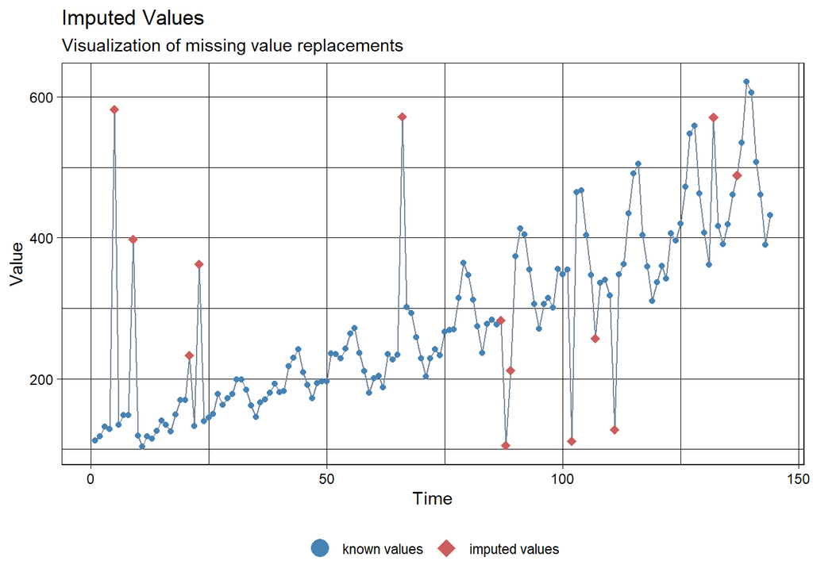

```r
imp_random <- na_random(tsAirgap)
ggplot_na_imputations(x_with_na = tsAirgap, x_with_imputations = imp_random)
```

# 4.7.1 na_replace. Replace all NAs with 0

# Prerequisite: Create Time series with missing values

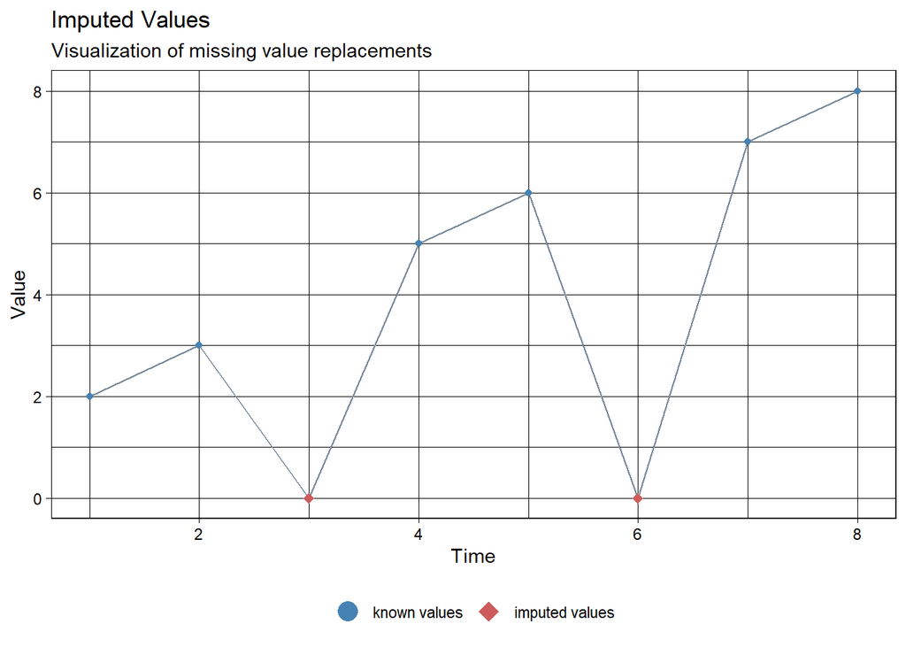

```r
x <- ts(c(2, 3, NA, 5, 6, NA, 7, 8))
imp_replace<-na_replace(x, fill = 0)
ggplot_na_imputations(x_with_na = x, x_with_imputations = imp_replace)
```

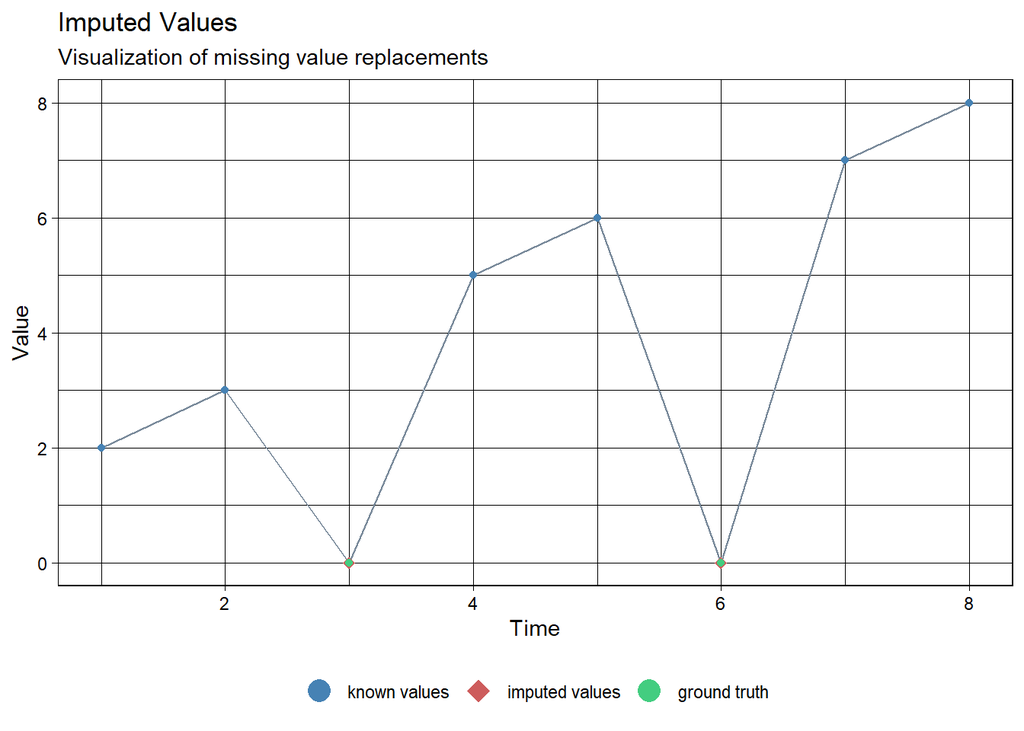

```r
x %>% na_replace(fill = 0) %>%
  ggplot_na_imputations(x_with_na = x, x_with_imputations = imp_replace)
```